# Project 2 Report

### Group Members (names and EIDs): Ria Bhatia (rnb982) & Ethan Benson (erb2994)

## Introduction

*For our comparison, we chose the following modeling approaches: linear regression, neural net (multilayer perceptron), kNN, and random forest. With these models, we used all of the available predictors, so we could truly understand the relationship between each predictor and the observations. In order to learn more about the relationships in the data, we used multiple exploratory data analysis techniques. First, we created a scatter plot to understand the relationship between CMAQ and AOD. Second, we conducted a PCA test, which was then used to produce a rotation plot, eigenvalues plot, and scatter plot to understand which variables might provide the strongest relations to average PM2.5 levels. This showed us that the log data of pollutants in various ranges overlap greatly, but based on preliminary testing, combining or removing them does not affect the performance of our models. After creating the models and conducting exploratory analysis, we hypothesized that either neural nets or random forest would be the best model. This would be because random forest incorporates ensembling decision trees which can handle many inputs and usually leads to better results and neural nets has a lot of hyper parameters we can tune. Such models work great for a lots of input data. We believed linear and KNN models would perform worse as KNN would suffer form the curse of dimensionality due to the large amount of variables and linear models are too simplistic for the possible complex relationships between so many variables. Our best model should should have an RMSE value below 2.*

## Data Wrangling

```r
# Reading in the libraries and data set
library(tidyverse)
library(broom)
library(tidymodels)
dat <- read_csv("pm25_data.csv.gz")
dat_split <- initial_split(dat)

#Split into train and test and saving the raw data for questions
dat_train_raw <- training(dat_split)
dat_test_raw <- testing(dat_split)

# Cleaning the data set
dat_clean <- dat |>
  select(-id, fips) |>
  select(where(is.numeric))

dat_train <- dat_train_raw |>
  select(-id, -fips) |>
  select(where(is.numeric))

dat_test <- dat_test_raw |>
  select(-id, -fips) |>
  select(where(is.numeric))
```

*In the above code chunk, we loaded the libraries and read in the data. We split the data into the train and test data sets, and then proceeded to clean the data sets by removing non-numeric variables and deleting identifiers, like id and fips.*

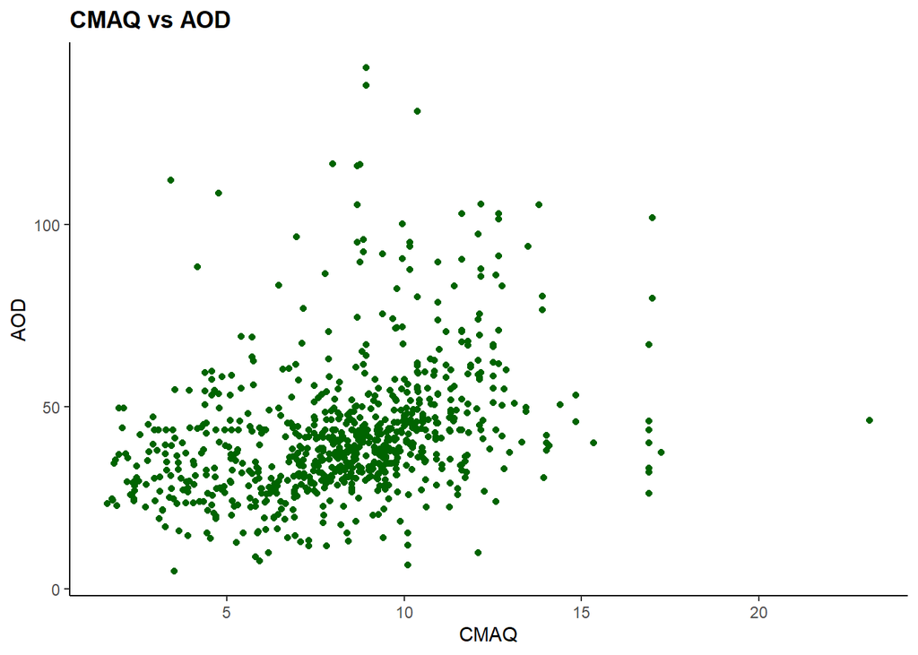

```r
# Data exploration

# Scatter plot of CMAQ vs AOD
dat_clean |>
  ggplot(aes(CMAQ, aod)) +
  geom_point(color = "darkgreen") +
  theme_classic() +
  labs(
    title = "CMAQ vs AOD",
    x = "CMAQ",
    y = "AOD"
  ) +
  theme(
    plot.title = element_text(face = "bold")
  )
```

*In the above visualization, we are able to understand the relationship between CMAQ and AOD. The two variables appear to have a moderately positive relationship, but there are many outliers also present.*

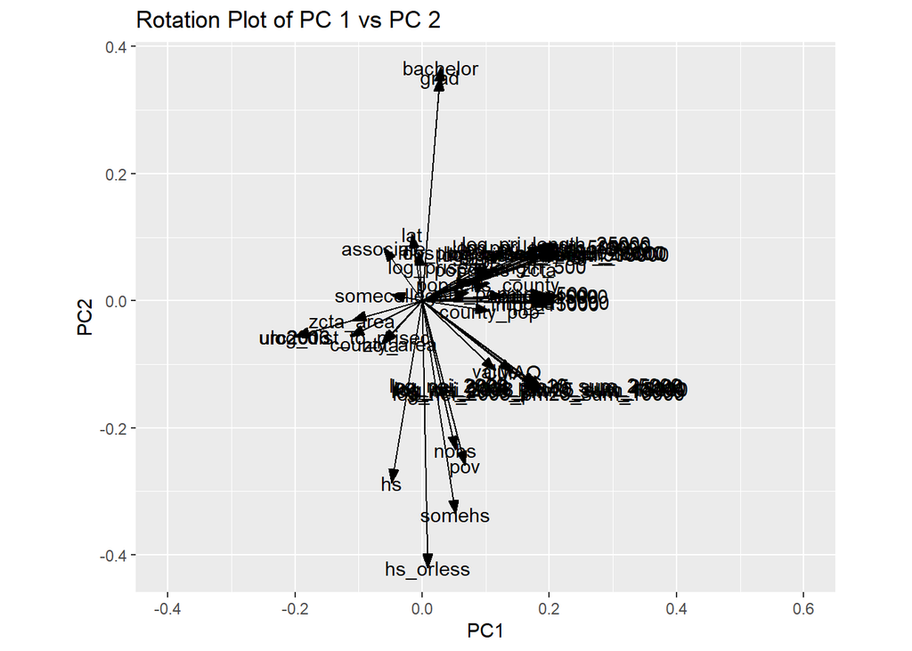

```r
# Data exploration continued - PCA

# PCA
pca_fit <- dat_clean |>
  select(where(is.numeric)) |>
  scale() |>
  prcomp()

# Rotation plot
arrow_style <- arrow(
  angle = 20, length = grid::unit(8, "pt"),
  ends = "first", type = "closed"
)

pca_fit |>
  tidy(matrix = "rotation") |>
  pivot_wider(
    names_from = "PC", values_from = "value",
    names_prefix = "PC"
  ) |>
  ggplot(aes(PC1, PC2)) +
  geom_segment(
    xend = 0, yend = 0,
    arrow = arrow_style
  ) +
  geom_text(aes(label = column)) +
  coord_fixed() +
  labs(
    title = "Rotation Plot of PC 1 vs PC 2"
  ) + xlim(-.4, .6)
```

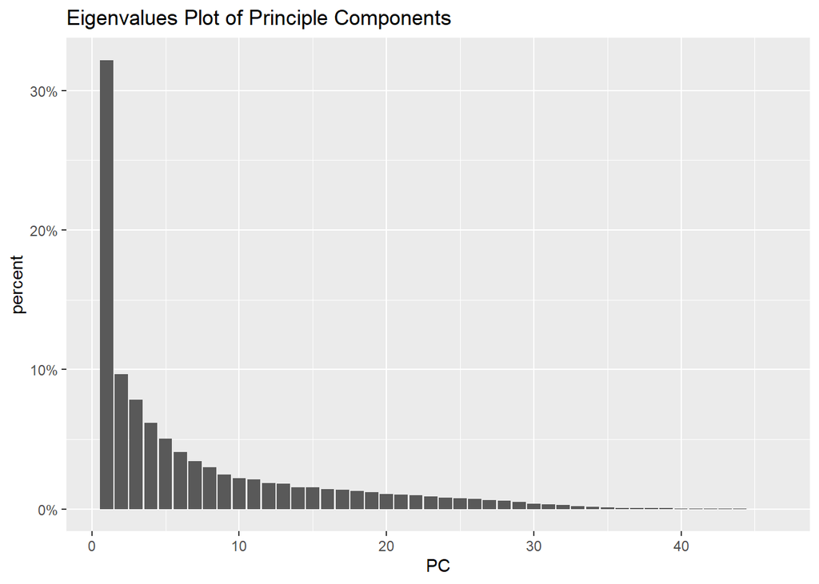

```r
# Eigenvalues plot
pca_fit |>
  tidy(matrix = "eigenvalues") |>
  ggplot(aes(PC, percent)) +
  geom_col() +
  scale_x_continuous() +
  scale_y_continuous(labels = scales::label_percent()) +
  labs(
    title = "Eigenvalues Plot of Principle Components"
  )
```

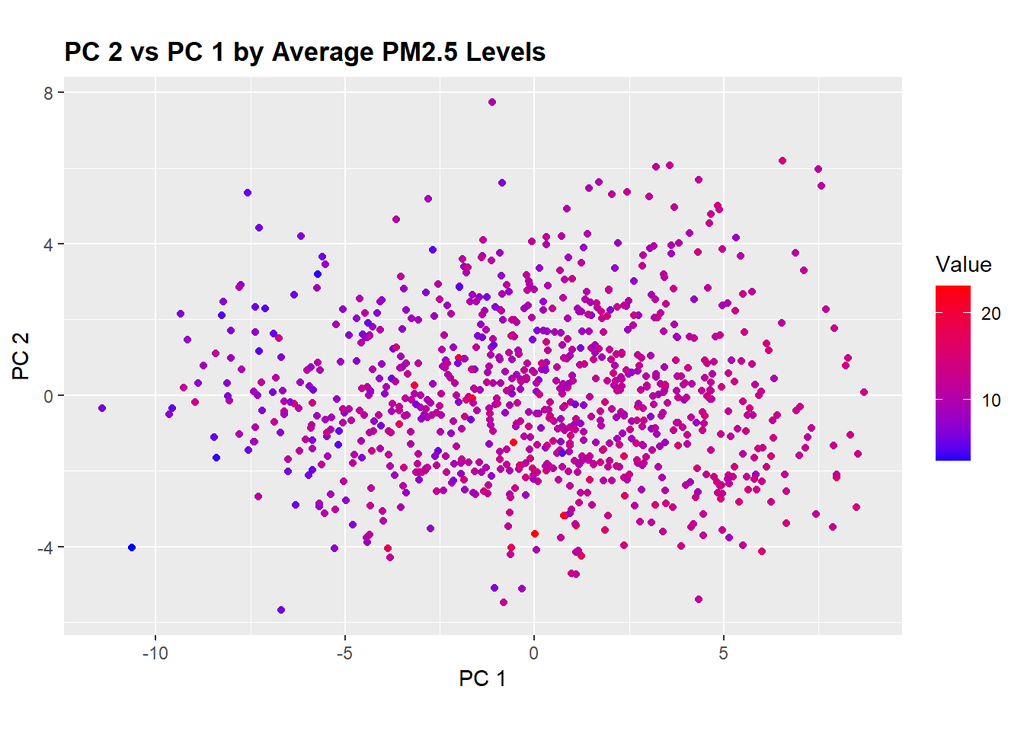

```r
# Scatter plot
pca_fit |>
  augment(dat_clean) |>
  ggplot(aes(x = .fittedPC1, y = .fittedPC2, color = dat_clean$value)) +
  geom_point() +
  labs(
    title = "PC 2 vs PC 1 by Average PM2.5 Levels",
    x = "PC 1",
    y = "PC 2"
  ) +
  theme_grey() +
  theme(
    plot.title = element_text(face = "bold")
  ) +
  coord_fixed()  +
  scale_color_gradient(
    name = "Value",
    low = "blue", high = "red", breaks = c(0, 10, 20, 30))
```

## Model Training

```r
#Linear Regression Model
rec <- dat_train |>
    recipe(value ~ .)

model <- linear_reg() |>
    set_engine("lm") |>
    set_mode("regression")

wf <- workflow() |>
    add_recipe(rec) |>
    add_model(model)

folds <- vfold_cv(dat_train, v = 10)

# Cross val
lin_final <- wf |>
    fit_resamples(resamples = folds)
```

```
## → A | warning: prediction from rank-deficient fit; consider predict(., rankdeficient="NA")
```

[output not shown]

```r
# Store metrics
res_lin <- lin_final |>
    collect_metrics()
```

```r
# Neural Net (Multilayer Perceptron)

rec <- dat_train |>
    recipe(value ~ .) |>
    step_normalize()

model <- mlp(hidden_units = tune(), penalty = tune(),
             epochs = tune()) |>
  set_engine("nnet") |>
  set_mode("regression")

wf <- workflow() |>
    add_model(model) |>
    add_recipe(rec)

# Tuning parameters
mlp_grid <- expand.grid(
  hidden_units = c(5, 10, 15),
  penalty = c(0, 0.01, 0.1),
  epochs = c(10, 50, 100)
)

folds <- vfold_cv(dat_train, v = 10)

#Tune Neural Net paraemters
res <- tune_grid(wf, resamples = folds, grid = mlp_grid)
```

```
## → A | warning: A correlation computation is required, but `estimate` is constant and has 0
##                standard deviation, resulting in a divide by 0 error. `NA` will be returned.
```

[output not shown]

```r
# Output best parameters
res_NN <- res |>
    show_best(metric = "rmse")
```

```r
# kNN

rec <- dat_train |>
    recipe(value ~ .) |>
    step_normalize()

## Tune for best k value

model <- nearest_neighbor(neighbors = tune("k")) |>
    set_engine("kknn") |>
    set_mode("regression")
wf <- workflow() |>
    add_model(model) |>
    add_recipe(rec)

folds <- vfold_cv(dat_train, v = 10)

res <- tune_grid(wf, resamples = folds,
                 grid =tibble(k = c(10, 12, 13, 15, 17, 18, 20, 25)))
# Output best k (Lowest RMSE)
res_kNN <- res |>
    show_best(metric = "rmse")
```

```r
library(ranger)
# Random Forest
rec <- dat_train |>
    recipe(value ~ .) |>
    step_normalize()

model <- rand_forest(mtry = tune("mtry"),
                     min_n = tune("min_n")) |>
    set_engine("ranger") |>
    set_mode("regression")

wf <- workflow() |>
    add_recipe(rec) |>
    add_model(model)

# Tune RF parameters
res <- tune_grid(wf, resamples = folds,
                 grid = expand.grid(mtry = c(1, 2, 5),
                                    min_n = c(3, 5)))

# OUtput best parameters
res_rf <- res |>
    show_best(metric = "rmse")
```

## Results

```r
# Output all RMSE for each model

all_model_metrics <- tibble(Model = c("Linear Reg", "Neural Net (MLP)", "kNN", "Random Forest"), RMSE = c(res_lin$mean[1], res_NN$mean[1], res_kNN$mean[1], res_rf$mean[1]))

all_model_metrics
```

```
## # A tibble: 4 × 2
##   Model             RMSE
##   <chr>            <dbl>
## 1 Linear Reg        2.14
## 2 Neural Net (MLP)  2.50
## 3 kNN               2.00
## 4 Random Forest     1.77
```

```r
# Create best final model (Random forest)
model <- rand_forest(mtry = 5,
                     min_n = 3) |>
    set_engine("ranger") |>
    set_mode("regression")

wf <- workflow() |>
    add_recipe(rec) |>
    add_model(model)

randFor_final <- wf |>
  last_fit(dat_split)

# Output metrics for final model
randFor_final |>
  collect_metrics()
```

```
## # A tibble: 2 × 4
##   .metric .estimator .estimate .config
##   <chr>   <chr>          <dbl> <chr>
## 1 rmse    standard       1.71  Preprocessor1_Model1
## 2 rsq     standard       0.634 Preprocessor1_Model1
```

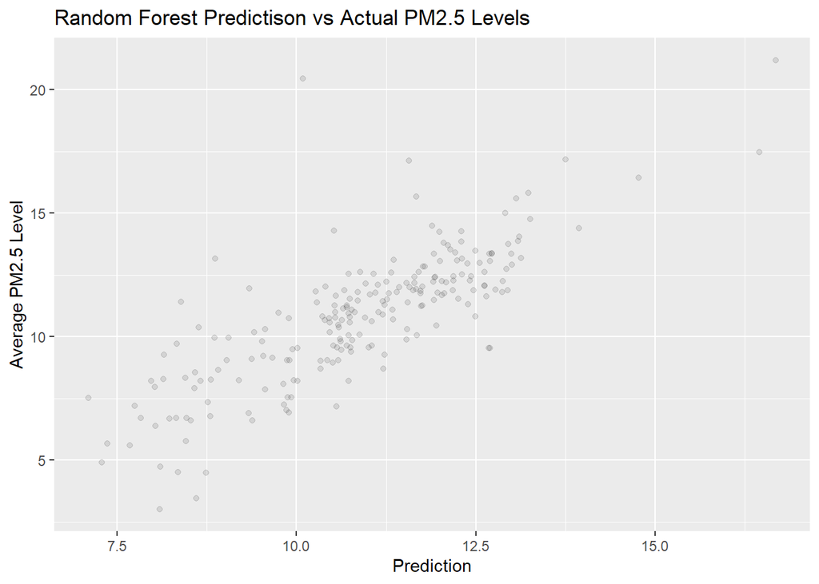

```r
# Prep test data
dat_test <- rec |>
    prep() |>
    bake(new_data = testing(dat_split))

# Scatter plot of predicted vs observed data points
randFor_final |>
    extract_fit_parsnip() |>
    augment(new_data = dat_test) |>
    select(value, .pred) |>
    ggplot(aes(.pred, value)) +
    geom_point(alpha = 1/10) +
    labs(title = "Random Forest Predictison vs Actual PM2.5 Levels", x = "Prediction", y = "Average PM2.5 Level")
```

**Our best model was Random Forest**

## Code for Primary Questions

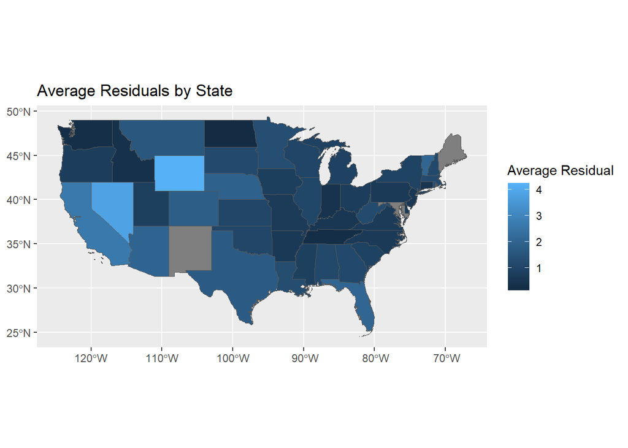

```r
# Code for primary questions

# Question 1: Geographic locations

library(rnaturalearth)
# Combine test data with predictions
aug_rf <- randFor_final |>
    extract_fit_parsnip() |>
    augment(new_data = dat_test_raw)

# Get avg residuals per state
state_resid <- aug_rf |>
  select(value, .pred, state, county, city) |>
  mutate(residuals = abs(value - .pred)) |>
  group_by(state) |>
  summarize(avg_resid = mean(residuals), count = n()) |>
  arrange(avg_resid) |>
  mutate(name = state) |>
  select(-state)

sf_us <- ne_states(
  country = "United States of America",
  returnclass='sf'
)
sf_us <- sf_us |>
  left_join(state_resid, by = "name")

# Map of US color map residuals
sf_us |>
  # exclude Alaska (US02), Hawaii (US15)
  filter(!code_local %in% c("US02", "US15")) |>
  ggplot() + geom_sf(aes(fill = avg_resid)) +
  labs(title = "Average Residuals by State") +
  scale_fill_continuous(
    name = "Average Residual"
  )
```

```r
# Question 2: Variables

# State specific numeric means
aug_rf |>
  mutate(residuals = abs(value - .pred)) |>
  select(-id, -fips) |>
  group_by(state) |>
  summarize(count = n(), across(where(is.numeric), mean, na.rm = TRUE)) |>
  arrange(residuals)
```

```
## # A tibble: 46 × 49
##    state count .pred value   lat    lon  CMAQ   zcta zcta_area zcta_pop imp_a500
##    <chr> <dbl> <dbl> <dbl> <dbl>  <dbl> <dbl>  <dbl>     <dbl>    <dbl>    <dbl>
##  1 Nort…     1  8.46  8.33  46.9  -96.9  4.83 58102     8.09e7   29850     0.324
##  2 Tenn…     1 12.0  12.3   35.0  -85.2  9.46 37412     2.26e7   20951    24.3
##  3 Wash…     2  9.45  9.46  47.1 -119.   4.03 99052     1.96e7   33951    40.9
##  4 Dist…     1 12.0  11.7   38.9  -77.0 10.4  20010     2.81e6   30138    35.0
##  5 Idaho     2  8.80  8.48  45.5 -116.   5.37 83752.    7.12e8   21684    10.7
##  6 Indi…     8 12.3  12.5   39.2  -86.7 11.2  46858.    5.15e7   24681    32.6
##  7 Conn…     6 10.9  10.5   41.4  -72.8  7.94  6481.    3.26e7   36675.   25.3
##  8 Kent…     5 12.1  11.9   38.0  -85.5  9.95 41361.    3.04e8   27197.   14.7
##  9 New …     4 12.6  12.4   40.3  -74.7 10.9   7578.    1.03e7   14813    22.3
## 10 Arka…     4 10.8  11.4   34.7  -92.3  9.86 72213     5.24e8   23685.   15.4
## # ℹ 36 more rows
## # ℹ 38 more variables: imp_a1000 <dbl>, imp_a5000 <dbl>, imp_a10000 <dbl>,
## #   imp_a15000 <dbl>, county_area <dbl>, county_pop <dbl>,
## #   log_dist_to_prisec <dbl>, log_pri_length_5000 <dbl>,
## #   log_pri_length_10000 <dbl>, log_pri_length_15000 <dbl>,
## #   log_pri_length_25000 <dbl>, log_prisec_length_500 <dbl>,
## #   log_prisec_length_1000 <dbl>, log_prisec_length_5000 <dbl>, …
```

```r
# Question 3: CMAQ & AOD
library(ranger)
# Random Forest
rec <- dat_train |>
    recipe(value ~ .) |>
    step_rm(CMAQ, aod)

model <- rand_forest(mtry = tune("mtry"),
                     min_n = tune("min_n")) |>
    set_engine("ranger") |>
    set_mode("regression")

wf <- workflow() |>
    add_recipe(rec) |>
    add_model(model)

## Fit RF over tuning parameters
res <- tune_grid(wf, resamples = folds,
                 grid = expand.grid(mtry = c(1, 2, 5),
                                    min_n = c(3, 5)))

# Output best parameters
res |>
    show_best(metric = "rmse")
```

```
## # A tibble: 5 × 8
##    mtry min_n .metric .estimator  mean     n std_err .config
##   <dbl> <dbl> <chr>   <chr>      <dbl> <int>   <dbl> <chr>
## 1     5     3 rmse    standard    1.85    10  0.0611 Preprocessor1_Model3
## 2     5     5 rmse    standard    1.87    10  0.0594 Preprocessor1_Model6
## 3     2     3 rmse    standard    1.98    10  0.0588 Preprocessor1_Model2
## 4     2     5 rmse    standard    1.98    10  0.0571 Preprocessor1_Model5
## 5     1     3 rmse    standard    2.04    10  0.0588 Preprocessor1_Model1
```

## Discussion

*To answer Question 4, it is notable that the data set does not include data from Alaska or Hawaii. We believe that the model would not perform as well due to Alaska and Hawaii both having significantly different environments compared to the rest of the states. On one hand, Alaska is much colder can the rest of the states, which can lead to different air quality patterns. On the other hand, Hawaii tends to have warmer weather conditions and is surrounded by a body of water, leading to differing air quality patterns as well.*

*In the process of conducting this project, we faced challenges in choosing appropriate models to conduct our analysis. For instance, in the beginning, we wanted to include a logistic regression model, which did not end up being feasible for our analysis as it is used for classification while this is a regression problem. Overall, we learned that conducting a thorough exploratory analysis to understand our data set would, in the end, help us choose models to evaluate. In our case, we ended up choosing 4 specific models that we predicted would be best for the provided data set.*

*Our best and final prediction model is the random forest model. We predicted that the random forest model would work well with the data since it incorporates ensemble learning and works well with complex, nonlinear relationships. Overall, the random forest model helped us understand the relationships within the air quality data set, including the many predictors present.*

*We would like to thank both Professor Peng and TA Bose for their guidance throughout the semester, especially during lecture and lab. WE modeled our code structure on the Github Examples given by Prof. Peng. This project includes contributions from 2 groups members. Ethan made the following contributions to the project: producing the models and results, editing the introduction, answering the primary questions, and writing the discussion. At the same time, Ria made the following contributions to the project: writing the introduction and discussion, conducting the exploratory analysis, and answering the primary questions.*